# RMarkdown and Regression

Michael D. Porter

Spring 2021 | Data Mining (SYS-6018) | University of Virginia

```r
#-- Settings for chunk options
knitr::opts_chunk$set(echo = TRUE,
                      warning = TRUE,
                      message = FALSE)

# See the R Markdown Reference Guide https://rstudio.com/wp-content/uploads/2015/03/rmarkdown-reference.pdf

# Note the chunk name 'setup' and argument `include = FALSE`
```

## Introduction

Suppose that we are consultants hired by a client to provide advice on how to improve sales of a particular product. The Advertising data set consists of the product sales (in thousands of units) in 200 different markets (e.g., cities), along with advertising budgets for the product in each of those markets for three different media: TV, radio, and newspaper (in thousands of dollars).

### Citation

The problem description and data are taken from **An Introduction to Statistical Learning** by James, Witten, Hastie, and Tibshirani. The advertising data is available from the textbook authors: https://www.statlearning.com/s/Advertising.csv.

## Getting Started

### Load Required Packages

```r
#-- Packages
library(broom)      # for tidy model output
library(knitr)      # for kable() tables
library(GGally)     # pairs plot ggpairs()
library(tidyverse)  # dplyr, ggplot2, etc
```

### Load Data

```r
#-- Load Data
url = 'https://www.statlearning.com/s/Advertising.csv'
advert = read_csv(url,
                  col_types = cols(X1='_')) # skip first column
#-- Show data
advert
```

```
## # A tibble: 200 x 4
##       TV radio newspaper sales
##    <dbl> <dbl>     <dbl> <dbl>
##  1 230.   37.8      69.2  22.1
##  2  44.5  39.3      45.1  10.4
##  3  17.2  45.9      69.3   9.3
##  4 152.   41.3      58.5  18.5
##  5 181.   10.8      58.4  12.9
##  6   8.7  48.9      75     7.2
##  7  57.5  32.8      23.5  11.8
##  8 120.   19.6      11.6  13.2
##  9   8.6   2.1       1     4.8
## 10 200.    2.6      21.2  10.6
## # … with 190 more rows
```

## Data Summary

```r
summary(advert)
```

```
##        TV             radio          newspaper          sales
##  Min.   :  0.70   Min.   : 0.000   Min.   :  0.30   Min.   : 1.60
##  1st Qu.: 74.38   1st Qu.: 9.975   1st Qu.: 12.75   1st Qu.:10.38
##  Median :149.75   Median :22.900   Median : 25.75   Median :12.90
##  Mean   :147.04   Mean   :23.264   Mean   : 30.55   Mean   :14.02
##  3rd Qu.:218.82   3rd Qu.:36.525   3rd Qu.: 45.10   3rd Qu.:17.40
##  Max.   :296.40   Max.   :49.600   Max.   :114.00   Max.   :27.00
```

The pairs plot shows the bivariate structure

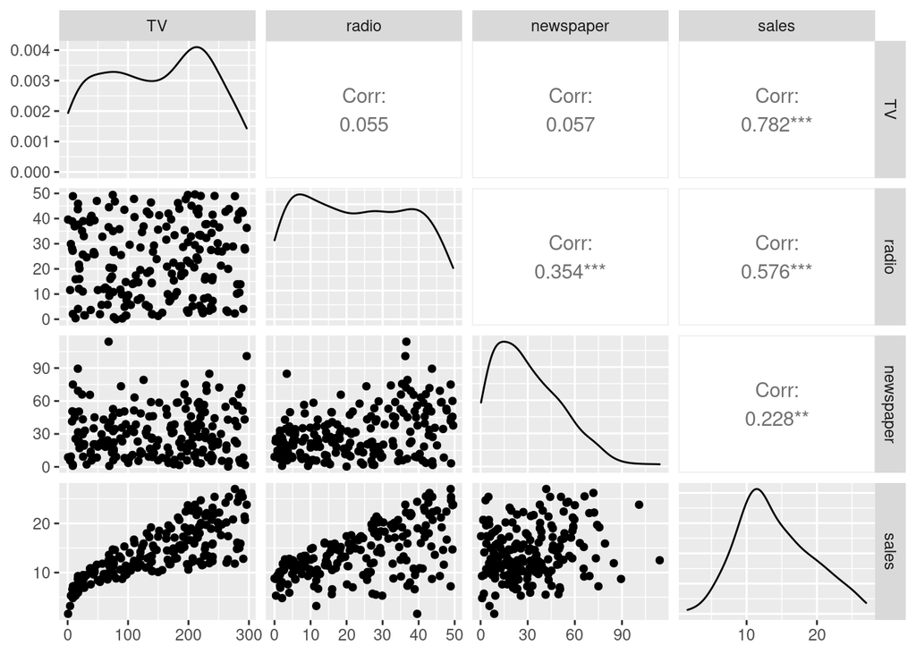

```r
library(GGally)
ggpairs(advert)
```

The plot of smoothed component fits help capture the relationship between the predictor variables and sales. Here is the scatterplot of TV and sales:

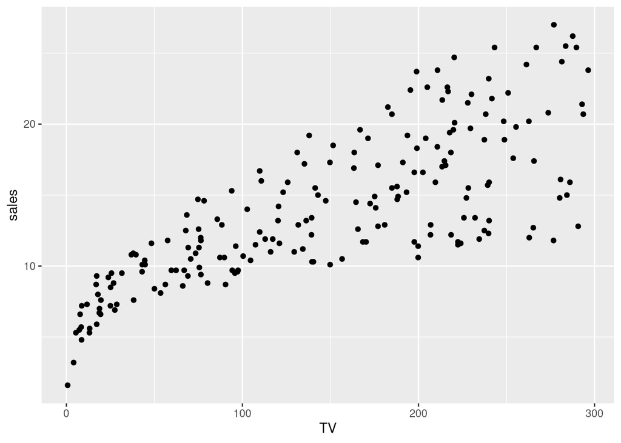

```r
ggplot(advert, aes(TV, sales)) + geom_point()
```

We can make three individual plots

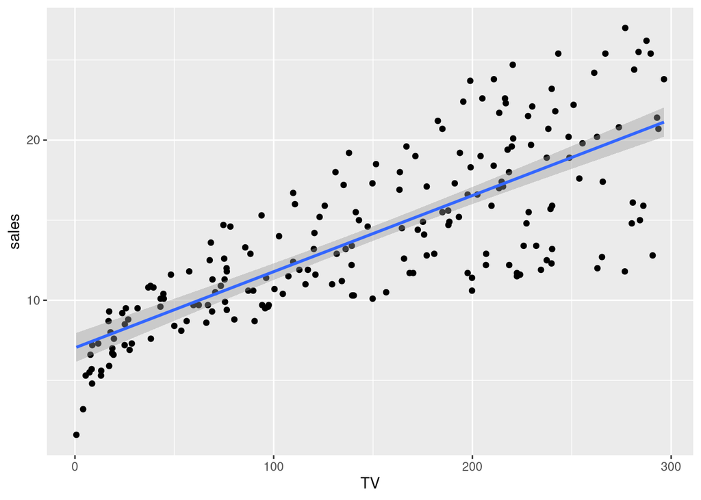

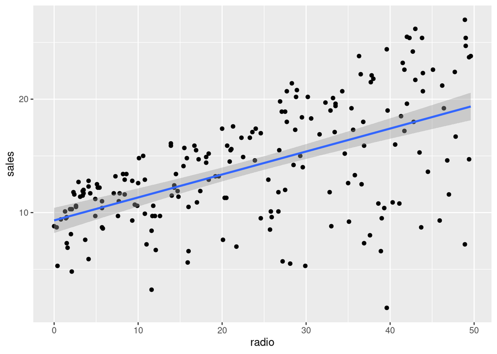

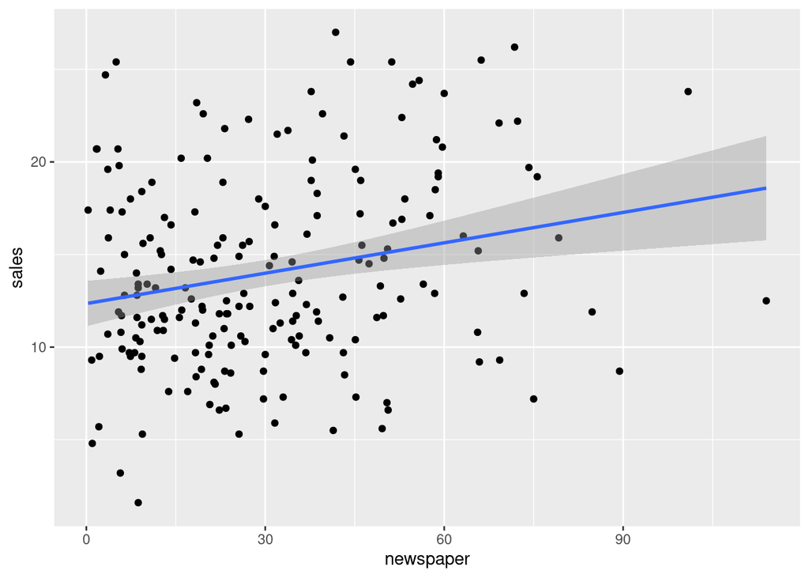

```r
ggplot(advert, aes(TV, sales)) + geom_point() + geom_smooth(method = "lm")
ggplot(advert, aes(radio, sales)) + geom_point() + geom_smooth(method = "lm")
ggplot(advert, aes(newspaper, sales)) + geom_point() + geom_smooth(method = "lm")
```

To use *faceting* to show all plots in same plot, I need to convert the data into *long* format:

```r
#- convert to "long" format
advert_long = advert %>%
  pivot_longer(cols=-sales,
               names_to="predictor",
               values_to="budget")

advert_long
```

```
## # A tibble: 600 x 3
##    sales predictor budget
##    <dbl> <chr>      <dbl>
##  1  22.1 TV         230.
##  2  22.1 radio       37.8
##  3  22.1 newspaper   69.2
##  4  10.4 TV          44.5
##  5  10.4 radio       39.3
##  6  10.4 newspaper   45.1
##  7   9.3 TV          17.2
##  8   9.3 radio       45.9
##  9   9.3 newspaper   69.3
## 10  18.5 TV         152.
## # … with 590 more rows
```

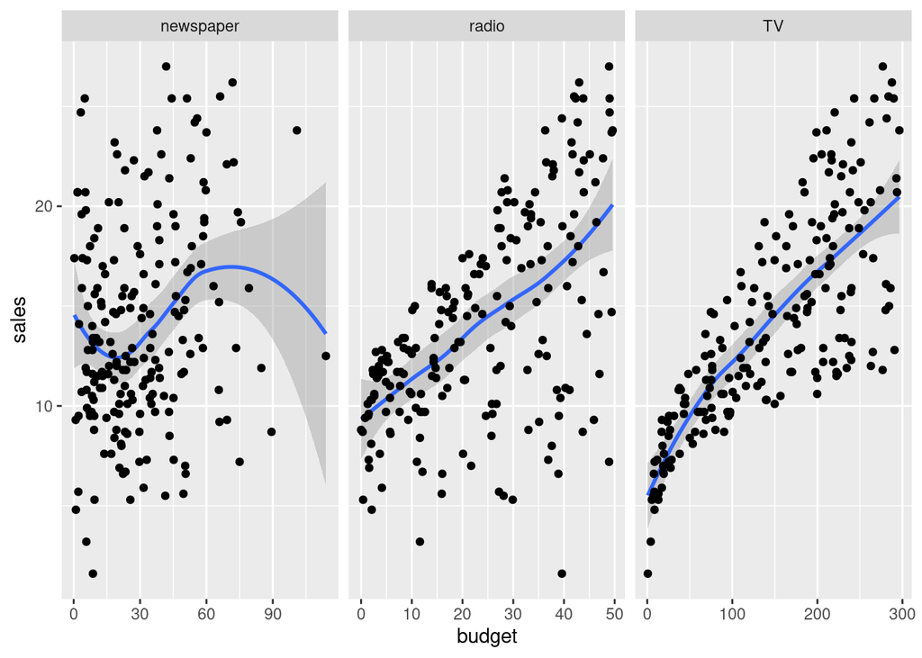

```r
advert_long %>%
  ggplot(aes(x=budget, y=sales)) +
  geom_smooth() +
  geom_point() +
  facet_wrap(~predictor, scales="free_x")
```

Note: see the [ggplot2 cheatsheet](https://github.com/rstudio/cheatsheets/blob/master/data-visualization-2.1.pdf) for help with ggplot2.

## Regression Models

Consider the advertising sales model that uses all three predictors
$$\text{sales} = \beta_0 + \beta_1 \times \text{(TV)} + \beta_2 \times \text{(radio)} +
\beta_3 \times \text{(newspaper)} + \text{error}$$

In R, the formula would be `Sales ~ TV + Radio + Newspaper` (the order of the predictor variables does not matter).

```r
library(broom)   # for tidy(), glance(), and augment() functions

#- fit full (main effects) model
lm.all = lm(sales ~ TV + radio + newspaper,
            data=advert)

#- model summary
summary(lm.all)
```

```
##
## Call:
## lm(formula = sales ~ TV + radio + newspaper, data = advert)
##
## Residuals:
##     Min      1Q  Median      3Q     Max
## -8.8277 -0.8908  0.2418  1.1893  2.8292
##
## Coefficients:
##              Estimate Std. Error t value Pr(>|t|)
## (Intercept)  2.938889   0.311908   9.422   <2e-16 ***
## TV           0.045765   0.001395  32.809   <2e-16 ***
## radio        0.188530   0.008611  21.893   <2e-16 ***
## newspaper   -0.001037   0.005871  -0.177     0.86
## ---
## Signif. codes:  0 '***' 0.001 '**' 0.01 '*' 0.05 '.' 0.1 ' ' 1
##
## Residual standard error: 1.686 on 196 degrees of freedom
## Multiple R-squared:  0.8972, Adjusted R-squared:  0.8956
## F-statistic: 570.3 on 3 and 196 DF,  p-value: < 2.2e-16
```

```r
#- tidy output (coefficients)
lm.all %>%
  broom::tidy(conf.int=TRUE) %>%
  knitr::kable(digits=3)
```

| term | estimate | std.error | statistic | p.value | conf.low | conf.high |
| --- | --- | --- | --- | --- | --- | --- |
| (Intercept) | 2.939 | 0.312 | 9.422 | 0.00 | 2.324 | 3.554 |
| TV | 0.046 | 0.001 | 32.809 | 0.00 | 0.043 | 0.049 |
| radio | 0.189 | 0.009 | 21.893 | 0.00 | 0.172 | 0.206 |
| newspaper | -0.001 | 0.006 | -0.177 | 0.86 | -0.013 | 0.011 |

```r
#- tidy model summary
lm.all %>%
  broom::glance()
```

```
## # A tibble: 1 x 12
##   r.squared adj.r.squared sigma statistic  p.value    df logLik   AIC   BIC
##       <dbl>         <dbl> <dbl>     <dbl>    <dbl> <dbl>  <dbl> <dbl> <dbl>
## 1     0.897         0.896  1.69      570. 1.58e-96     3  -386.  782.  799.
## # … with 3 more variables: deviance <dbl>, df.residual <int>, nobs <int>
```

```r
#- add model output to the original data
lm.all %>% broom::augment()
```

```
## # A tibble: 200 x 10
##    sales    TV radio newspaper .fitted  .resid    .hat .sigma .cooksd .std.resid
##    <dbl> <dbl> <dbl>     <dbl>   <dbl>   <dbl>   <dbl>  <dbl>   <dbl>      <dbl>
##  1  22.1 230.   37.8      69.2   20.5   1.58   0.0252    1.69 5.80e-3     0.947
##  2  10.4  44.5  39.3      45.1   12.3  -1.94   0.0194    1.68 6.67e-3    -1.16
##  3   9.3  17.2  45.9      69.3   12.3  -3.01   0.0392    1.68 3.38e-2    -1.82
##  4  18.5 152.   41.3      58.5   17.6   0.902  0.0166    1.69 1.23e-3     0.540
##  5  12.9 181.   10.8      58.4   13.2  -0.289  0.0235    1.69 1.81e-4    -0.173
##  6   7.2   8.7  48.9      75     12.5  -5.28   0.0475    1.64 1.28e-1    -3.21
##  7  11.8  57.5  32.8      23.5   11.7   0.0702 0.0144    1.69 6.45e-6     0.0420
##  8  13.2 120.   19.6      11.6   12.1   1.08   0.00918   1.69 9.55e-4     0.642
##  9   4.8   8.6   2.1       1      3.73  1.07   0.0307    1.69 3.31e-3     0.646
## 10  10.6 200.    2.6      21.2   12.6  -1.95   0.0171    1.68 5.95e-3    -1.17
## # … with 190 more rows
```

### Simpler Model

We can consider other models. You probably noticed that `newspaper` is not statistically significant in the full model, so we can try the model without it:

```r
#-- Only TV + Radio
lm.TVRadio = lm(sales ~ TV + radio,
                data=advert)
summary(lm.TVRadio)
```

```
##
## Call:
## lm(formula = sales ~ TV + radio, data = advert)
##
## Residuals:
##     Min      1Q  Median      3Q     Max
## -8.7977 -0.8752  0.2422  1.1708  2.8328
##
## Coefficients:
##             Estimate Std. Error t value Pr(>|t|)
## (Intercept)  2.92110    0.29449   9.919   <2e-16 ***
## TV           0.04575    0.00139  32.909   <2e-16 ***
## radio        0.18799    0.00804  23.382   <2e-16 ***
## ---
## Signif. codes:  0 '***' 0.001 '**' 0.01 '*' 0.05 '.' 0.1 ' ' 1
##
## Residual standard error: 1.681 on 197 degrees of freedom
## Multiple R-squared:  0.8972, Adjusted R-squared:  0.8962
## F-statistic: 859.6 on 2 and 197 DF,  p-value: < 2.2e-16
```

### Interaction Effects

We have found that the best model so far is the one that uses `TV` and `Radio` to predict the value of `Sales`.

Specifically, the least squares model is:

$$\widehat{\text{sales}} = 2.921 + 0.046 \times \text{(TV)} + 0.188 \times \text{(radio)}$$

- So a one unit increase in `TV` would suggest a 0.046 unit increase in `Sales`, no matter the budget allocated to `Radio`
- But what if spending money on `Radio` advertising actually increases the effectiveness of the `TV` advertising?
  - So `TV` effects should increase as `Radio` increases
  - E.g., spending 1/2 of a $100,000 budget on `TV` and `Radio` may increase `Sales` more than allocating the entire amount to only `TV` or only `Radio`
  - In marketing, this is the *synergy* effect. In statistics, this is known as an *interaction* effect.

#### Modeling Interactions

Consider the linear regression model with two variables and an interaction effect

$$Y = \beta_0 + \beta_1 X_1 + \beta_2 X_2 + \beta_3 X_1 X_2 + \epsilon$$

This model relaxes the additive structure, while maintaining the linear structure. Consider the equation re-written

$$\begin{align*}
Y &= \beta_0 + (\beta_1 + \beta_3 X_2)X_1 + \beta_2 X_2 + \epsilon \\
&= \beta_0 + \tilde{\beta}_1 X_1 + \beta_2 X_2 + \epsilon
\end{align*}$$
where $\tilde{\beta}_1 = (\beta_1 + \beta_3 X_2)$.

- Since $\tilde{\beta}_1$ changes with $X_2$, the effect of $X_1$ on $Y$ is no longer constant.
  - Adjusting $X_2$ will change the impact of $X_1$ on $Y$

In R, use the notation `X_1:X_2` to include an interaction effect:

```r
lm.synergy = lm(sales ~ TV + radio + TV:radio,
                data=advert)
summary(lm.synergy)
```

```
##
## Call:
## lm(formula = sales ~ TV + radio + TV:radio, data = advert)
##
## Residuals:
##     Min      1Q  Median      3Q     Max
## -6.3366 -0.4028  0.1831  0.5948  1.5246
##
## Coefficients:
##              Estimate Std. Error t value Pr(>|t|)
## (Intercept) 6.750e+00  2.479e-01  27.233   <2e-16 ***
## TV          1.910e-02  1.504e-03  12.699   <2e-16 ***
## radio       2.886e-02  8.905e-03   3.241   0.0014 **
## TV:radio    1.086e-03  5.242e-05  20.727   <2e-16 ***
## ---
## Signif. codes:  0 '***' 0.001 '**' 0.01 '*' 0.05 '.' 0.1 ' ' 1
##
## Residual standard error: 0.9435 on 196 degrees of freedom
## Multiple R-squared:  0.9678, Adjusted R-squared:  0.9673
## F-statistic:  1963 on 3 and 196 DF,  p-value: < 2.2e-16
```

### Prediction

In R, the `predict()` function will return the predicted values from a fitted regression model. Besides the model, the function needs the $X$ values (the `newdata` argument) for making predictions.  
- Type `?predict.lm` to read the help pages  
- The `object` argument is the `lm` model  
- The `newdata` must be a `data.frame`/`tibble`

```r
#-- predict the Sales for a budget with TV = 50
#   ($50,000) and Radio = 20 ($20,000)
pred_data = tibble(TV=50, radio=20, newspaper=0)
predict(lm.TVRadio,
        newdata = pred_data,
        interval = "prediction") # or "confidence"
```

```
##        fit      lwr      upr
## 1 8.968725 5.633862 12.30359
```

Multiple values (grid of predictor values)

```r
#- grid of values at which to predict
pred_grid =
  expand_grid(TV = seq(0, 50, by=25),
              radio = seq(0, 60, by=20),
              newspaper = 0)

#- add predictions to the grid (using bind_cols)
bind_cols(
  pred_grid,
  predict(lm.TVRadio, pred_grid, interval = "prediction") %>% as_tibble()
)
```

```
## # A tibble: 12 x 6
##       TV radio newspaper   fit    lwr   upr
##    <dbl> <dbl>     <dbl> <dbl>  <dbl> <dbl>
##  1     0     0         0  2.92 -0.445  6.29
##  2     0    20         0  6.68  3.33  10.0
##  3     0    40         0 10.4   7.08  13.8
##  4     0    60         0 14.2  10.8   17.6
##  5    25     0         0  4.06  0.706  7.42
##  6    25    20         0  7.82  4.48  11.2
##  7    25    40         0 11.6   8.23  14.9
##  8    25    60         0 15.3  12.0   18.7
##  9    50     0         0  5.21  1.86   8.56
## 10    50    20         0  8.97  5.63  12.3
## 11    50    40         0 12.7   9.38  16.1
## 12    50    60         0 16.5  13.1   19.9
```

```r
#- add predictions to the grid (using augment)
augment(lm.TVRadio, newdata = pred_grid, interval = "prediction")
```

```
## # A tibble: 12 x 6
##       TV radio newspaper .fitted .lower .upper
##    <dbl> <dbl>     <dbl>   <dbl>  <dbl>  <dbl>
##  1     0     0         0    2.92 -0.445   6.29
##  2     0    20         0    6.68  3.33   10.0
##  3     0    40         0   10.4   7.08   13.8
##  4     0    60         0   14.2  10.8    17.6
##  5    25     0         0    4.06  0.706   7.42
##  6    25    20         0    7.82  4.48   11.2
##  7    25    40         0   11.6   8.23   14.9
##  8    25    60         0   15.3  12.0    18.7
##  9    50     0         0    5.21  1.86    8.56
## 10    50    20         0    8.97  5.63   12.3
## 11    50    40         0   12.7   9.38   16.1
## 12    50    60         0   16.5  13.1    19.9
```

```r
#- add predictions to the grid (using mutate)
pred_grid %>%
  mutate(TVRadio = predict(lm.TVRadio, .),
         synergy = predict(lm.synergy, .))
```

```
## # A tibble: 12 x 5
##       TV radio newspaper TVRadio synergy
##    <dbl> <dbl>     <dbl>   <dbl>   <dbl>
##  1     0     0         0    2.92    6.75
##  2     0    20         0    6.68    7.33
##  3     0    40         0   10.4     7.90
##  4     0    60         0   14.2     8.48
##  5    25     0         0    4.06    7.23
##  6    25    20         0    7.82    8.35
##  7    25    40         0   11.6     9.47
##  8    25    60         0   15.3    10.6
##  9    50     0         0    5.21    7.71
## 10    50    20         0    8.97    9.37
## 11    50    40         0   12.7    11.0
## 12    50    60         0   16.5    12.7
```

### Residual Analysis

```r
## Residual Analysis
residuals_wide = advert %>%
  mutate(TVRadio = lm.TVRadio$residuals,
        synergy = lm.synergy$residuals)

residuals = residuals_wide %>%
  pivot_longer(c(TVRadio, synergy), names_to = "model", values_to = "r")
```

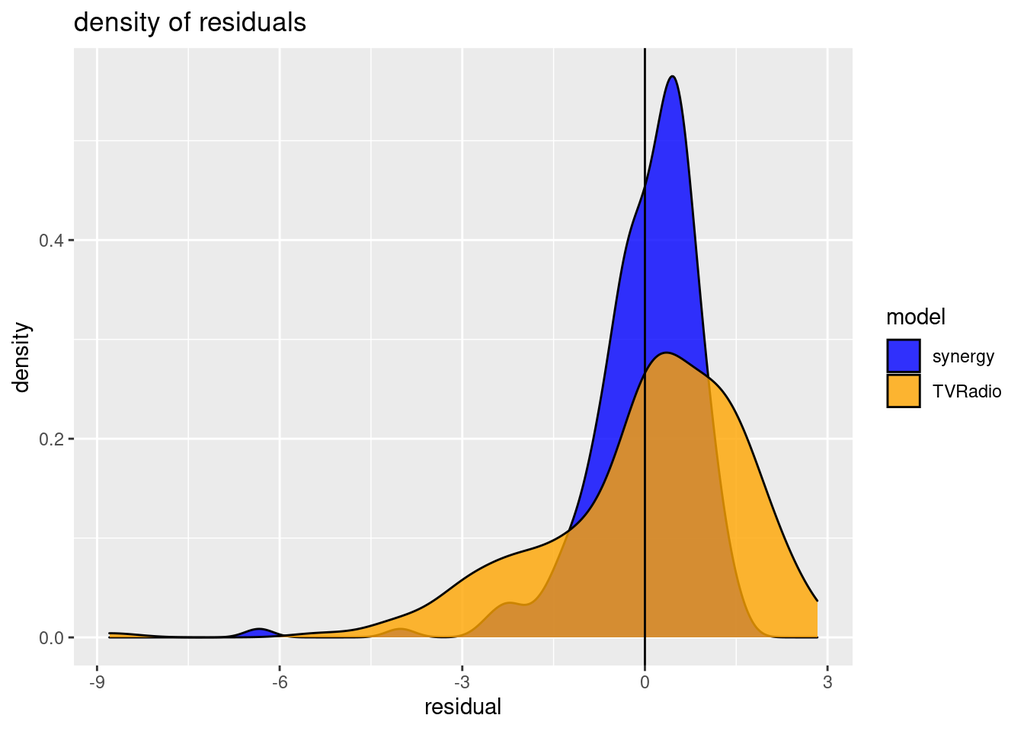

```r
#-- Density of residuals
ggplot(residuals, aes(r, fill=model)) + geom_density(alpha=.8) +
  geom_vline(xintercept=0) +
  scale_fill_manual(values=c("blue", "orange")) +
  labs(x="residual", title="density of residuals")
```

NOTE: I could still use the “wide” data and two geoms:

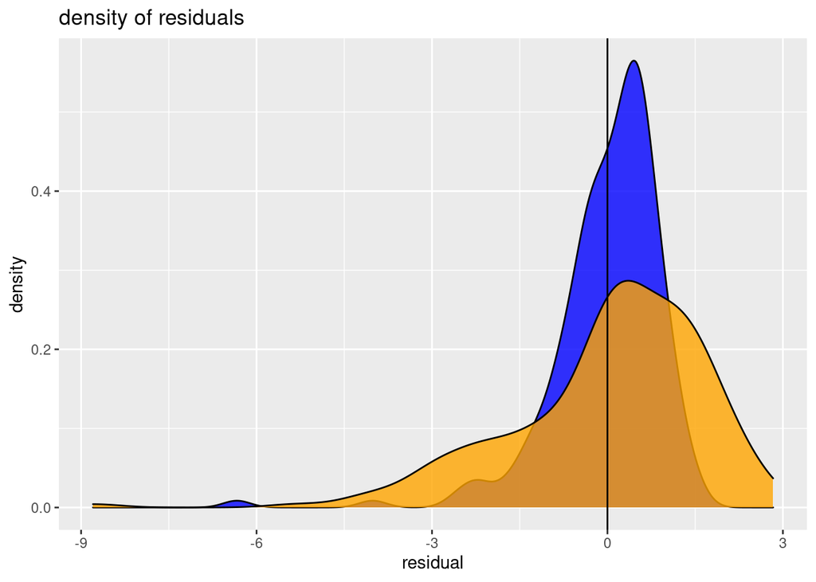

```r
residuals_wide %>%
  ggplot() +
  geom_density(aes(synergy), fill = "blue", alpha=.8) +
  geom_density(aes(TVRadio), fill = "orange", alpha=.8) +
  geom_vline(xintercept=0) +
  labs(x="residual", title="density of residuals")
```

The residuals on `radio` looks decent (especially on synergy model)

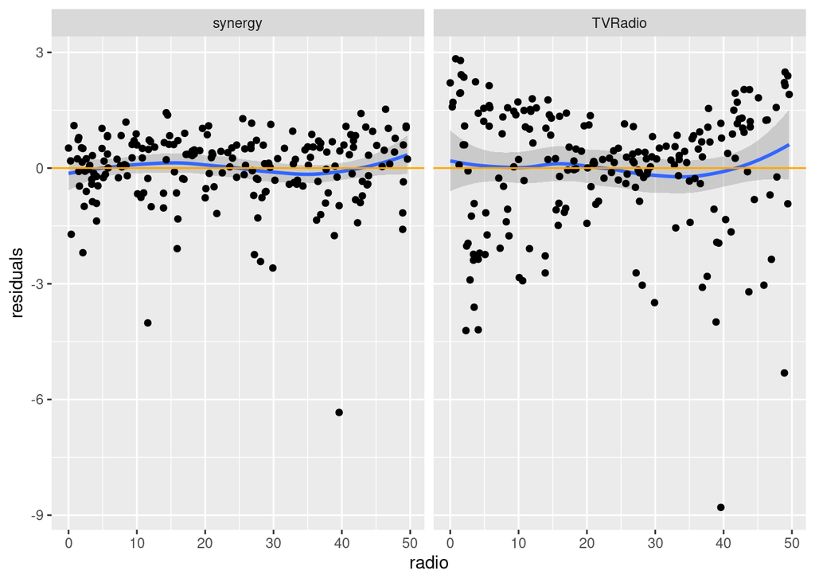

```r
#-- Radio: residual scatterplot
ggplot(residuals, aes(radio, r)) + geom_smooth() + geom_point() +
    geom_hline(yintercept=0, color="orange") +
    facet_wrap(~model) +  labs(y="residuals")
```

But the residuals on TV shows some unaccounted for patterns, even with synergy model.

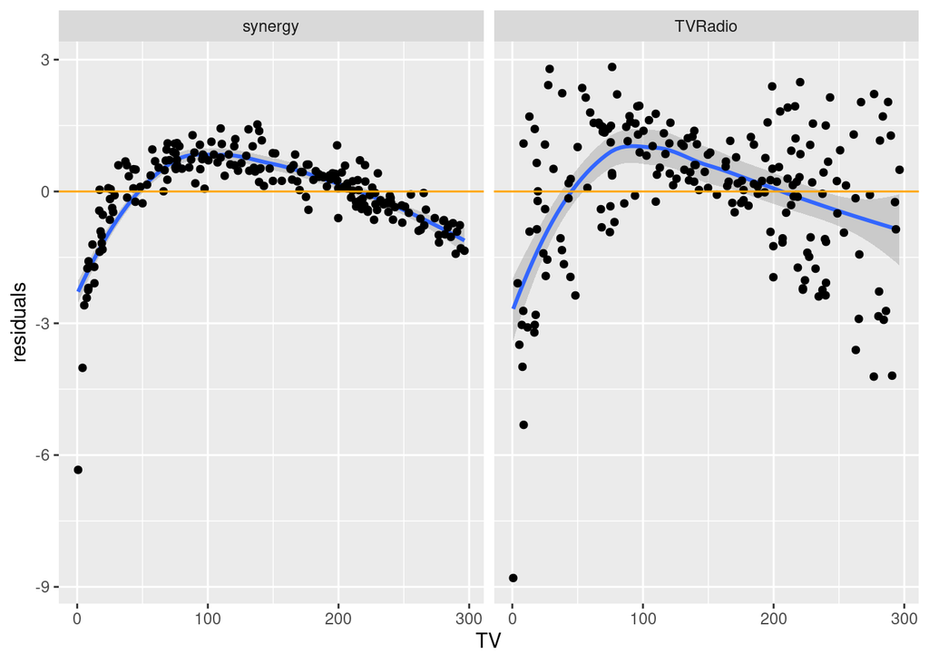

```r
#-- TV: residual scatterplot
ggplot(residuals, aes(TV, r)) + geom_smooth() + geom_point() +
  geom_hline(yintercept=0, color="orange") +
  facet_wrap(~model) +  labs(y="residuals")
```

This suggests add a transformation to `TV`, perhaps a log transformation

```r
#-- Best models of ones I considered

#-- use log(TV) only
best1 = lm(sales ~ log(TV) + radio + TV:radio, data=advert)
summary(best1)
```

```
##
## Call:
## lm(formula = sales ~ log(TV) + radio + TV:radio, data = advert)
##
## Residuals:
##      Min       1Q   Median       3Q      Max
## -0.86111 -0.20709  0.00901  0.19113  0.76612
##
## Coefficients:
##              Estimate Std. Error t value Pr(>|t|)
## (Intercept) 1.886e-01  1.676e-01   1.125    0.262
## log(TV)     1.967e+00  3.448e-02  57.041   <2e-16 ***
## radio       4.578e-02  2.629e-03  17.410   <2e-16 ***
## radio:TV    1.025e-03  1.409e-05  72.756   <2e-16 ***
## ---
## Signif. codes:  0 '***' 0.001 '**' 0.01 '*' 0.05 '.' 0.1 ' ' 1
##
## Residual standard error: 0.3036 on 196 degrees of freedom
## Multiple R-squared:  0.9967, Adjusted R-squared:  0.9966
## F-statistic: 1.952e+04 on 3 and 196 DF,  p-value: < 2.2e-16
```

```r
#-- include main effects log(TV) + TV
best2 = lm(sales ~ TV + log(TV) + radio + TV:radio, data=advert)
summary(best2)
```

```
##
## Call:
## lm(formula = sales ~ TV + log(TV) + radio + TV:radio, data = advert)
##
## Residuals:
##      Min       1Q   Median       3Q      Max
## -0.85606 -0.20548  0.01615  0.19011  0.77385
##
## Coefficients:
##              Estimate Std. Error t value Pr(>|t|)
## (Intercept) 2.310e-01  1.774e-01   1.302    0.194
## TV          4.888e-04  6.629e-04   0.737    0.462
## log(TV)     1.943e+00  4.723e-02  41.148   <2e-16 ***
## radio       4.668e-02  2.902e-03  16.087   <2e-16 ***
## TV:radio    1.018e-03  1.697e-05  60.015   <2e-16 ***
## ---
## Signif. codes:  0 '***' 0.001 '**' 0.01 '*' 0.05 '.' 0.1 ' ' 1
##
## Residual standard error: 0.304 on 195 degrees of freedom
## Multiple R-squared:  0.9967, Adjusted R-squared:  0.9966
## F-statistic: 1.461e+04 on 4 and 195 DF,  p-value: < 2.2e-16
```

With an $R^2$ of 0.997, we may have found how the data were generated!

```r
R = mutate(advert, r=best1$residuals)
```

The residuals using the best model look much cleaner

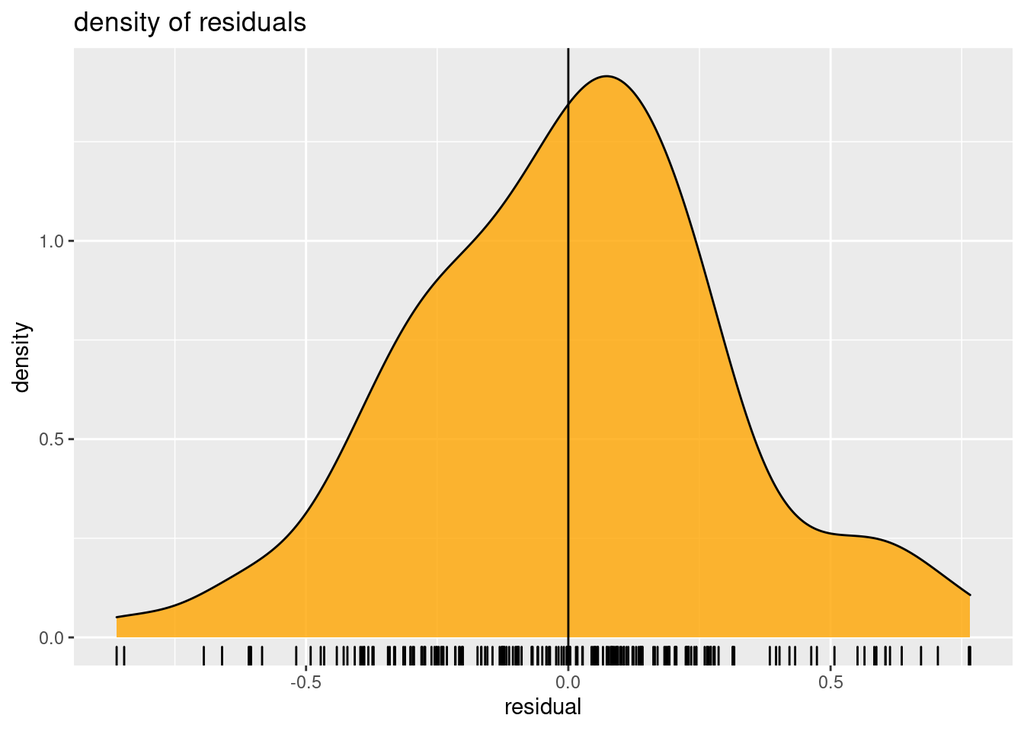

```r
#-- Density of residuals
ggplot(R, aes(r)) + geom_density(alpha=.8, fill="orange") +
  geom_rug() +
  geom_vline(xintercept=0) +
  labs(x="residual", title="density of residuals")
```

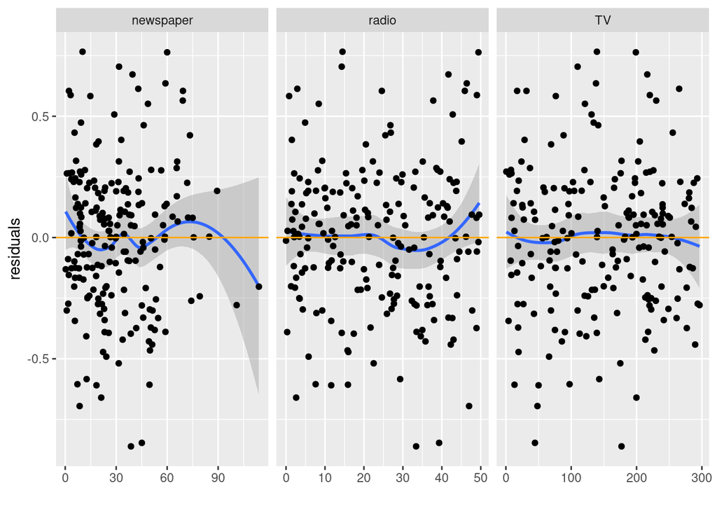

```r
#-- residual scatterplot
R %>%
  gather(variable, value, -sales, -r) %>%
  ggplot(aes(value, r)) + geom_smooth() + geom_point() +
    geom_hline(yintercept=0, color="orange") +
    facet_wrap(~variable, scales="free_x") +  labs(x="", y="residuals")
```